# Risk Factor Analysis

## Outcome Variable

**Outcome Variable:** y_rate_len

## Predictor Variables

**Intervention Variable:** safeh20

**Adjustment Set:**

- arm
- sex
- W_mage
- meducyrs
- feducyrs
- hhwealth_quart
- hfoodsec
- W_mhtcm
- W_nrooms
- W_nchldlt5
- W_parity
- impfloor
- impsan
- delta_W_mage
- delta_meducyrs
- delta_feducyrs
- delta_hhwealth_quart
- delta_hfoodsec
- delta_W_mhtcm
- delta_W_nrooms
- delta_W_nchldlt5
- delta_W_parity
- delta_impfloor
- delta_impsan

## Stratifying Variables

The analysis was stratified on these variable(s):

- agecat
- studyid
- country

## Data Summary

| agecat | studyid | country | safeh20 | n_cell | n |
| --- | --- | --- | --- | --- | --- |
| 0-3 months | ki0047075b-MAL-ED | BANGLADESH | 0 | 237 | 237 |
| 0-3 months | ki0047075b-MAL-ED | BANGLADESH | 1 | 0 | 237 |
| 0-3 months | ki0047075b-MAL-ED | BRAZIL | 0 | 124 | 124 |
| 0-3 months | ki0047075b-MAL-ED | BRAZIL | 1 | 0 | 124 |
| 0-3 months | ki0047075b-MAL-ED | INDIA | 0 | 194 | 194 |
| 0-3 months | ki0047075b-MAL-ED | INDIA | 1 | 0 | 194 |
| 0-3 months | ki0047075b-MAL-ED | NEPAL | 0 | 170 | 171 |
| 0-3 months | ki0047075b-MAL-ED | NEPAL | 1 | 1 | 171 |
| 0-3 months | ki0047075b-MAL-ED | PERU | 0 | 238 | 249 |
| 0-3 months | ki0047075b-MAL-ED | PERU | 1 | 11 | 249 |
| 0-3 months | ki0047075b-MAL-ED | SOUTH AFRICA | 0 | 180 | 213 |
| 0-3 months | ki0047075b-MAL-ED | SOUTH AFRICA | 1 | 33 | 213 |
| 0-3 months | ki0047075b-MAL-ED | TANZANIA, UNITED REPUBLIC OF | 0 | 70 | 225 |
| 0-3 months | ki0047075b-MAL-ED | TANZANIA, UNITED REPUBLIC OF | 1 | 155 | 225 |
| 0-3 months | ki1017093-NIH-Birth | BANGLADESH | 0 | 2 | 566 |
| 0-3 months | ki1017093-NIH-Birth | BANGLADESH | 1 | 564 | 566 |
| 0-3 months | ki1017093b-PROVIDE | BANGLADESH | 0 | 0 | 634 |
| 0-3 months | ki1017093b-PROVIDE | BANGLADESH | 1 | 634 | 634 |
| 0-3 months | ki1017093c-NIH-Crypto | BANGLADESH | 0 | 0 | 720 |
| 0-3 months | ki1017093c-NIH-Crypto | BANGLADESH | 1 | 720 | 720 |
| 0-3 months | ki1114097-CONTENT | PERU | 0 | 1 | 6 |
| 0-3 months | ki1114097-CONTENT | PERU | 1 | 5 | 6 |
| 0-3 months | kiGH5241-JiVitA-3 | BANGLADESH | 0 | 70 | 40058 |
| 0-3 months | kiGH5241-JiVitA-3 | BANGLADESH | 1 | 39988 | 40058 |
| 0-3 months | kiGH5241-JiVitA-4 | BANGLADESH | 0 | 0 | 3610 |
| 0-3 months | kiGH5241-JiVitA-4 | BANGLADESH | 1 | 3610 | 3610 |
| 3-6 months | ki0047075b-MAL-ED | BANGLADESH | 0 | 231 | 231 |
| 3-6 months | ki0047075b-MAL-ED | BANGLADESH | 1 | 0 | 231 |
| 3-6 months | ki0047075b-MAL-ED | BRAZIL | 0 | 141 | 141 |
| 3-6 months | ki0047075b-MAL-ED | BRAZIL | 1 | 0 | 141 |

[output cut: 80 more lines]

The following strata were considered:

- agecat: 0-3 months, studyid: ki0047075b-MAL-ED, country: BANGLADESH
- agecat: 0-3 months, studyid: ki0047075b-MAL-ED, country: BRAZIL
- agecat: 0-3 months, studyid: ki0047075b-MAL-ED, country: INDIA
- agecat: 0-3 months, studyid: ki0047075b-MAL-ED, country: NEPAL
- agecat: 0-3 months, studyid: ki0047075b-MAL-ED, country: PERU
- agecat: 0-3 months, studyid: ki0047075b-MAL-ED, country: SOUTH AFRICA
- agecat: 0-3 months, studyid: ki0047075b-MAL-ED, country: TANZANIA, UNITED REPUBLIC OF
- agecat: 0-3 months, studyid: ki1017093-NIH-Birth, country: BANGLADESH
- agecat: 0-3 months, studyid: ki1017093b-PROVIDE, country: BANGLADESH
- agecat: 0-3 months, studyid: ki1017093c-NIH-Crypto, country: BANGLADESH
- agecat: 0-3 months, studyid: ki1114097-CONTENT, country: PERU
- agecat: 0-3 months, studyid: kiGH5241-JiVitA-3, country: BANGLADESH
- agecat: 0-3 months, studyid: kiGH5241-JiVitA-4, country: BANGLADESH
- agecat: 12-24 months, studyid: ki0047075b-MAL-ED, country: BANGLADESH
- agecat: 12-24 months, studyid: ki0047075b-MAL-ED, country: BRAZIL
- agecat: 12-24 months, studyid: ki0047075b-MAL-ED, country: INDIA
- agecat: 12-24 months, studyid: ki0047075b-MAL-ED, country: NEPAL
- agecat: 12-24 months, studyid: ki0047075b-MAL-ED, country: PERU
- agecat: 12-24 months, studyid: ki0047075b-MAL-ED, country: SOUTH AFRICA
- agecat: 12-24 months, studyid: ki0047075b-MAL-ED, country: TANZANIA, UNITED REPUBLIC OF
- agecat: 12-24 months, studyid: ki1017093-NIH-Birth, country: BANGLADESH
- agecat: 12-24 months, studyid: ki1017093b-PROVIDE, country: BANGLADESH
- agecat: 12-24 months, studyid: ki1017093c-NIH-Crypto, country: BANGLADESH
- agecat: 12-24 months, studyid: ki1114097-CONTENT, country: PERU
- agecat: 12-24 months, studyid: ki1148112-LCNI-5, country: MALAWI
- agecat: 12-24 months, studyid: kiGH5241-JiVitA-3, country: BANGLADESH
- agecat: 12-24 months, studyid: kiGH5241-JiVitA-4, country: BANGLADESH
- agecat: 3-6 months, studyid: ki0047075b-MAL-ED, country: BANGLADESH
- agecat: 3-6 months, studyid: ki0047075b-MAL-ED, country: BRAZIL
- agecat: 3-6 months, studyid: ki0047075b-MAL-ED, country: INDIA
- agecat: 3-6 months, studyid: ki0047075b-MAL-ED, country: NEPAL
- agecat: 3-6 months, studyid: ki0047075b-MAL-ED, country: PERU
- agecat: 3-6 months, studyid: ki0047075b-MAL-ED, country: SOUTH AFRICA
- agecat: 3-6 months, studyid: ki0047075b-MAL-ED, country: TANZANIA, UNITED REPUBLIC OF
- agecat: 3-6 months, studyid: ki1017093-NIH-Birth, country: BANGLADESH
- agecat: 3-6 months, studyid: ki1017093b-PROVIDE, country: BANGLADESH
- agecat: 3-6 months, studyid: ki1017093c-NIH-Crypto, country: BANGLADESH
- agecat: 3-6 months, studyid: ki1114097-CONTENT, country: PERU
- agecat: 3-6 months, studyid: kiGH5241-JiVitA-3, country: BANGLADESH
- agecat: 3-6 months, studyid: kiGH5241-JiVitA-4, country: BANGLADESH
- agecat: 6-12 months, studyid: ki0047075b-MAL-ED, country: BANGLADESH
- agecat: 6-12 months, studyid: ki0047075b-MAL-ED, country: BRAZIL
- agecat: 6-12 months, studyid: ki0047075b-MAL-ED, country: INDIA
- agecat: 6-12 months, studyid: ki0047075b-MAL-ED, country: NEPAL
- agecat: 6-12 months, studyid: ki0047075b-MAL-ED, country: PERU
- agecat: 6-12 months, studyid: ki0047075b-MAL-ED, country: SOUTH AFRICA
- agecat: 6-12 months, studyid: ki0047075b-MAL-ED, country: TANZANIA, UNITED REPUBLIC OF
- agecat: 6-12 months, studyid: ki1000304b-SAS-FoodSuppl, country: INDIA
- agecat: 6-12 months, studyid: ki1017093-NIH-Birth, country: BANGLADESH
- agecat: 6-12 months, studyid: ki1017093b-PROVIDE, country: BANGLADESH
- agecat: 6-12 months, studyid: ki1017093c-NIH-Crypto, country: BANGLADESH
- agecat: 6-12 months, studyid: ki1114097-CONTENT, country: PERU
- agecat: 6-12 months, studyid: ki1148112-LCNI-5, country: MALAWI
- agecat: 6-12 months, studyid: kiGH5241-JiVitA-3, country: BANGLADESH
- agecat: 6-12 months, studyid: kiGH5241-JiVitA-4, country: BANGLADESH

### Dropped Strata

Some strata were dropped due to rare outcomes:

- agecat: 0-3 months, studyid: ki0047075b-MAL-ED, country: BANGLADESH
- agecat: 0-3 months, studyid: ki0047075b-MAL-ED, country: BRAZIL
- agecat: 0-3 months, studyid: ki0047075b-MAL-ED, country: INDIA
- agecat: 0-3 months, studyid: ki0047075b-MAL-ED, country: NEPAL
- agecat: 0-3 months, studyid: ki1017093-NIH-Birth, country: BANGLADESH
- agecat: 0-3 months, studyid: ki1017093b-PROVIDE, country: BANGLADESH
- agecat: 0-3 months, studyid: ki1017093c-NIH-Crypto, country: BANGLADESH
- agecat: 0-3 months, studyid: ki1114097-CONTENT, country: PERU
- agecat: 0-3 months, studyid: kiGH5241-JiVitA-4, country: BANGLADESH
- agecat: 3-6 months, studyid: ki0047075b-MAL-ED, country: BANGLADESH
- agecat: 3-6 months, studyid: ki0047075b-MAL-ED, country: BRAZIL
- agecat: 3-6 months, studyid: ki0047075b-MAL-ED, country: INDIA
- agecat: 3-6 months, studyid: ki0047075b-MAL-ED, country: NEPAL
- agecat: 3-6 months, studyid: ki1017093-NIH-Birth, country: BANGLADESH
- agecat: 3-6 months, studyid: ki1017093b-PROVIDE, country: BANGLADESH
- agecat: 3-6 months, studyid: ki1017093c-NIH-Crypto, country: BANGLADESH
- agecat: 3-6 months, studyid: ki1114097-CONTENT, country: PERU
- agecat: 3-6 months, studyid: kiGH5241-JiVitA-4, country: BANGLADESH
- agecat: 6-12 months, studyid: ki0047075b-MAL-ED, country: BANGLADESH
- agecat: 6-12 months, studyid: ki0047075b-MAL-ED, country: BRAZIL
- agecat: 6-12 months, studyid: ki0047075b-MAL-ED, country: INDIA
- agecat: 6-12 months, studyid: ki0047075b-MAL-ED, country: NEPAL
- agecat: 6-12 months, studyid: ki1000304b-SAS-FoodSuppl, country: INDIA
- agecat: 6-12 months, studyid: ki1017093-NIH-Birth, country: BANGLADESH
- agecat: 6-12 months, studyid: ki1017093b-PROVIDE, country: BANGLADESH
- agecat: 6-12 months, studyid: ki1017093c-NIH-Crypto, country: BANGLADESH
- agecat: 6-12 months, studyid: ki1114097-CONTENT, country: PERU
- agecat: 6-12 months, studyid: kiGH5241-JiVitA-4, country: BANGLADESH
- agecat: 12-24 months, studyid: ki0047075b-MAL-ED, country: BANGLADESH
- agecat: 12-24 months, studyid: ki0047075b-MAL-ED, country: BRAZIL
- agecat: 12-24 months, studyid: ki0047075b-MAL-ED, country: INDIA
- agecat: 12-24 months, studyid: ki0047075b-MAL-ED, country: NEPAL
- agecat: 12-24 months, studyid: ki1017093-NIH-Birth, country: BANGLADESH
- agecat: 12-24 months, studyid: ki1017093b-PROVIDE, country: BANGLADESH
- agecat: 12-24 months, studyid: ki1017093c-NIH-Crypto, country: BANGLADESH
- agecat: 12-24 months, studyid: ki1114097-CONTENT, country: PERU
- agecat: 12-24 months, studyid: kiGH5241-JiVitA-4, country: BANGLADESH

## Methods Detail

We’re interested in the causal parameters $E[Y_a]$ for all values of $a \in \mathcal{A}$. These parameters represent the mean outcome if, possibly contrary to fact, we intervened to set all units to have $A=a$. Under the randomization and positivity assumptions, these are identified by the statistical parameters $\psi_a=E_W[E_{Y|A,W}(Y|A=a,W)]$. In addition, we’re interested in the mean of $Y$, $E[Y]$ under no intervention (the observed mean). We will estimate these parameters by using SuperLearner to fit the relevant likelihood factors – $E_{Y|A,W}(Y|A=a,W)$ and $p(A=a|W)$, and then updating our likelihood fit using a joint TMLE.

For unadjusted analyses ($W=\{\}$), initial likelihoods were estimated using Lrnr_glm to estimate the simple $E(Y|A)$ and Lrnr_mean to estimate $p(A)$. For adjusted analyses, a small library containing Lrnr_glmnet, Lrnr_xgboost, and Lrnr_mean was used.

# Results Detail

## Results Plots

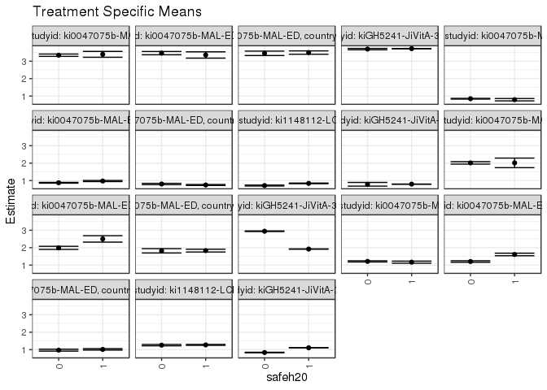

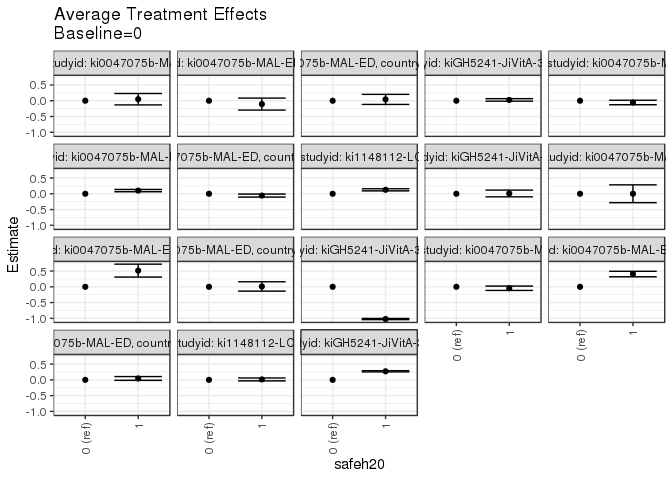

## Results Table

### Parameter: TSM

| agecat | studyid | country | intervention_level | baseline_level | estimate | ci_lower | ci_upper |
| --- | --- | --- | --- | --- | --- | --- | --- |
| 0-3 months | ki0047075b-MAL-ED | PERU | 0 | NA | 3.3429477 | 3.2764474 | 3.4094480 |
| 0-3 months | ki0047075b-MAL-ED | PERU | 1 | NA | 3.3923344 | 3.2244034 | 3.5602654 |
| 0-3 months | ki0047075b-MAL-ED | SOUTH AFRICA | 0 | NA | 3.4619138 | 3.3678167 | 3.5560110 |
| 0-3 months | ki0047075b-MAL-ED | SOUTH AFRICA | 1 | NA | 3.3549332 | 3.1744355 | 3.5354308 |
| 0-3 months | ki0047075b-MAL-ED | TANZANIA, UNITED REPUBLIC OF | 0 | NA | 3.4505485 | 3.3236757 | 3.5774213 |
| 0-3 months | ki0047075b-MAL-ED | TANZANIA, UNITED REPUBLIC OF | 1 | NA | 3.4933302 | 3.3961111 | 3.5905493 |
| 0-3 months | kiGH5241-JiVitA-3 | BANGLADESH | 0 | NA | 3.6928873 | 3.6536622 | 3.7321124 |
| 0-3 months | kiGH5241-JiVitA-3 | BANGLADESH | 1 | NA | 3.7186636 | 3.7083032 | 3.7290239 |
| 3-6 months | ki0047075b-MAL-ED | PERU | 0 | NA | 2.0141349 | 1.9448680 | 2.0834019 |
| 3-6 months | ki0047075b-MAL-ED | PERU | 1 | NA | 2.0149851 | 1.7409478 | 2.2890224 |
| 3-6 months | ki0047075b-MAL-ED | SOUTH AFRICA | 0 | NA | 1.9884922 | 1.9005515 | 2.0764329 |
| 3-6 months | ki0047075b-MAL-ED | SOUTH AFRICA | 1 | NA | 2.5022392 | 2.3179421 | 2.6865363 |
| 3-6 months | ki0047075b-MAL-ED | TANZANIA, UNITED REPUBLIC OF | 0 | NA | 1.8207687 | 1.6966045 | 1.9449328 |
| 3-6 months | ki0047075b-MAL-ED | TANZANIA, UNITED REPUBLIC OF | 1 | NA | 1.8322199 | 1.7508981 | 1.9135416 |
| 3-6 months | kiGH5241-JiVitA-3 | BANGLADESH | 0 | NA | 2.9428554 | 2.9270355 | 2.9586753 |
| 3-6 months | kiGH5241-JiVitA-3 | BANGLADESH | 1 | NA | 1.9203003 | 1.9098402 | 1.9307605 |
| 6-12 months | ki0047075b-MAL-ED | PERU | 0 | NA | 1.2139710 | 1.1788461 | 1.2490960 |
| 6-12 months | ki0047075b-MAL-ED | PERU | 1 | NA | 1.1685746 | 1.1092442 | 1.2279050 |
| 6-12 months | ki0047075b-MAL-ED | SOUTH AFRICA | 0 | NA | 1.2058854 | 1.1614490 | 1.2503218 |
| 6-12 months | ki0047075b-MAL-ED | SOUTH AFRICA | 1 | NA | 1.6108028 | 1.5367542 | 1.6848514 |
| 6-12 months | ki0047075b-MAL-ED | TANZANIA, UNITED REPUBLIC OF | 0 | NA | 0.9705654 | 0.9158973 | 1.0252336 |
| 6-12 months | ki0047075b-MAL-ED | TANZANIA, UNITED REPUBLIC OF | 1 | NA | 1.0147676 | 0.9737922 | 1.0557430 |
| 6-12 months | ki1148112-LCNI-5 | MALAWI | 0 | NA | 1.2584045 | 1.2180522 | 1.2987568 |
| 6-12 months | ki1148112-LCNI-5 | MALAWI | 1 | NA | 1.2724193 | 1.2435733 | 1.3012652 |
| 6-12 months | kiGH5241-JiVitA-3 | BANGLADESH | 0 | NA | 0.8355946 | 0.8180417 | 0.8531476 |
| 6-12 months | kiGH5241-JiVitA-3 | BANGLADESH | 1 | NA | 1.1067503 | 1.1000113 | 1.1134893 |
| 12-24 months | ki0047075b-MAL-ED | PERU | 0 | NA | 0.8465096 | 0.8245582 | 0.8684609 |
| 12-24 months | ki0047075b-MAL-ED | PERU | 1 | NA | 0.7912850 | 0.7235229 | 0.8590471 |
| 12-24 months | ki0047075b-MAL-ED | SOUTH AFRICA | 0 | NA | 0.8749739 | 0.8518468 | 0.8981010 |
| 12-24 months | ki0047075b-MAL-ED | SOUTH AFRICA | 1 | NA | 0.9755235 | 0.9434113 | 1.0076357 |
| 12-24 months | ki0047075b-MAL-ED | TANZANIA, UNITED REPUBLIC OF | 0 | NA | 0.8037440 | 0.7653415 | 0.8421465 |
| 12-24 months | ki0047075b-MAL-ED | TANZANIA, UNITED REPUBLIC OF | 1 | NA | 0.7471821 | 0.7187679 | 0.7755962 |
| 12-24 months | ki1148112-LCNI-5 | MALAWI | 0 | NA | 0.7140895 | 0.6861070 | 0.7420720 |
| 12-24 months | ki1148112-LCNI-5 | MALAWI | 1 | NA | 0.8399814 | 0.8216578 | 0.8583050 |
| 12-24 months | kiGH5241-JiVitA-3 | BANGLADESH | 0 | NA | 0.7867339 | 0.6802720 | 0.8931958 |
| 12-24 months | kiGH5241-JiVitA-3 | BANGLADESH | 1 | NA | 0.7966277 | 0.7913290 | 0.8019265 |

### Parameter: E(Y)

| agecat | studyid | country | intervention_level | baseline_level | estimate | ci_lower | ci_upper |
| --- | --- | --- | --- | --- | --- | --- | --- |
| 0-3 months | ki0047075b-MAL-ED | PERU | NA | NA | 3.3389528 | 3.2747209 | 3.4031847 |
| 0-3 months | ki0047075b-MAL-ED | SOUTH AFRICA | NA | NA | 3.4372874 | 3.3434154 | 3.5311594 |
| 0-3 months | ki0047075b-MAL-ED | TANZANIA, UNITED REPUBLIC OF | NA | NA | 3.4800204 | 3.4022349 | 3.5578058 |
| 0-3 months | kiGH5241-JiVitA-3 | BANGLADESH | NA | NA | 3.7184741 | 3.7081307 | 3.7288174 |
| 3-6 months | ki0047075b-MAL-ED | PERU | NA | NA | 2.0141715 | 1.9468382 | 2.0815048 |
| 3-6 months | ki0047075b-MAL-ED | SOUTH AFRICA | NA | NA | 1.9844707 | 1.9033268 | 2.0656145 |
| 3-6 months | ki0047075b-MAL-ED | TANZANIA, UNITED REPUBLIC OF | NA | NA | 1.8286113 | 1.7605412 | 1.8966813 |
| 3-6 months | kiGH5241-JiVitA-3 | BANGLADESH | NA | NA | 1.9201827 | 1.9097195 | 1.9306459 |
| 6-12 months | ki0047075b-MAL-ED | PERU | NA | NA | 1.2121791 | 1.1783399 | 1.2460182 |
| 6-12 months | ki0047075b-MAL-ED | SOUTH AFRICA | NA | NA | 1.1896669 | 1.1483348 | 1.2309989 |
| 6-12 months | ki0047075b-MAL-ED | TANZANIA, UNITED REPUBLIC OF | NA | NA | 1.0012814 | 0.9640416 | 1.0385213 |
| 6-12 months | ki1148112-LCNI-5 | MALAWI | NA | NA | 1.2790810 | 1.2528925 | 1.3052695 |
| 6-12 months | kiGH5241-JiVitA-3 | BANGLADESH | NA | NA | 1.1069007 | 1.1001595 | 1.1136418 |
| 12-24 months | ki0047075b-MAL-ED | PERU | NA | NA | 0.8443972 | 0.8230714 | 0.8657230 |
| 12-24 months | ki0047075b-MAL-ED | SOUTH AFRICA | NA | NA | 0.8691564 | 0.8467327 | 0.8915801 |
| 12-24 months | ki0047075b-MAL-ED | TANZANIA, UNITED REPUBLIC OF | NA | NA | 0.7647577 | 0.7413956 | 0.7881199 |
| 12-24 months | ki1148112-LCNI-5 | MALAWI | NA | NA | 0.8407809 | 0.8238743 | 0.8576875 |
| 12-24 months | kiGH5241-JiVitA-3 | BANGLADESH | NA | NA | 0.7966099 | 0.7912995 | 0.8019202 |

### Parameter: ATE

| agecat | studyid | country | intervention_level | baseline_level | estimate | ci_lower | ci_upper |
| --- | --- | --- | --- | --- | --- | --- | --- |
| 0-3 months | ki0047075b-MAL-ED | PERU | 0 | 0 | 0.0000000 | 0.0000000 | 0.0000000 |
| 0-3 months | ki0047075b-MAL-ED | PERU | 1 | 0 | 0.0493867 | -0.1312498 | 0.2300232 |
| 0-3 months | ki0047075b-MAL-ED | SOUTH AFRICA | 0 | 0 | 0.0000000 | 0.0000000 | 0.0000000 |
| 0-3 months | ki0047075b-MAL-ED | SOUTH AFRICA | 1 | 0 | -0.1069807 | -0.2969758 | 0.0830145 |
| 0-3 months | ki0047075b-MAL-ED | TANZANIA, UNITED REPUBLIC OF | 0 | 0 | 0.0000000 | 0.0000000 | 0.0000000 |
| 0-3 months | ki0047075b-MAL-ED | TANZANIA, UNITED REPUBLIC OF | 1 | 0 | 0.0427817 | -0.1170502 | 0.2026137 |
| 0-3 months | kiGH5241-JiVitA-3 | BANGLADESH | 0 | 0 | 0.0000000 | 0.0000000 | 0.0000000 |
| 0-3 months | kiGH5241-JiVitA-3 | BANGLADESH | 1 | 0 | 0.0257762 | -0.0142173 | 0.0657697 |
| 3-6 months | ki0047075b-MAL-ED | PERU | 0 | 0 | 0.0000000 | 0.0000000 | 0.0000000 |
| 3-6 months | ki0047075b-MAL-ED | PERU | 1 | 0 | 0.0008501 | -0.2817768 | 0.2834770 |
| 3-6 months | ki0047075b-MAL-ED | SOUTH AFRICA | 0 | 0 | 0.0000000 | 0.0000000 | 0.0000000 |
| 3-6 months | ki0047075b-MAL-ED | SOUTH AFRICA | 1 | 0 | 0.5137470 | 0.3091659 | 0.7183281 |
| 3-6 months | ki0047075b-MAL-ED | TANZANIA, UNITED REPUBLIC OF | 0 | 0 | 0.0000000 | 0.0000000 | 0.0000000 |
| 3-6 months | ki0047075b-MAL-ED | TANZANIA, UNITED REPUBLIC OF | 1 | 0 | 0.0114512 | -0.1369710 | 0.1598734 |
| 3-6 months | kiGH5241-JiVitA-3 | BANGLADESH | 0 | 0 | 0.0000000 | 0.0000000 | 0.0000000 |
| 3-6 months | kiGH5241-JiVitA-3 | BANGLADESH | 1 | 0 | -1.0225551 | -1.0412105 | -1.0038997 |
| 6-12 months | ki0047075b-MAL-ED | PERU | 0 | 0 | 0.0000000 | 0.0000000 | 0.0000000 |
| 6-12 months | ki0047075b-MAL-ED | PERU | 1 | 0 | -0.0453965 | -0.1143447 | 0.0235518 |
| 6-12 months | ki0047075b-MAL-ED | SOUTH AFRICA | 0 | 0 | 0.0000000 | 0.0000000 | 0.0000000 |
| 6-12 months | ki0047075b-MAL-ED | SOUTH AFRICA | 1 | 0 | 0.4049174 | 0.3175446 | 0.4922901 |
| 6-12 months | ki0047075b-MAL-ED | TANZANIA, UNITED REPUBLIC OF | 0 | 0 | 0.0000000 | 0.0000000 | 0.0000000 |
| 6-12 months | ki0047075b-MAL-ED | TANZANIA, UNITED REPUBLIC OF | 1 | 0 | 0.0442022 | -0.0154151 | 0.1038195 |
| 6-12 months | ki1148112-LCNI-5 | MALAWI | 0 | 0 | 0.0000000 | 0.0000000 | 0.0000000 |
| 6-12 months | ki1148112-LCNI-5 | MALAWI | 1 | 0 | 0.0140148 | -0.0324212 | 0.0604507 |
| 6-12 months | kiGH5241-JiVitA-3 | BANGLADESH | 0 | 0 | 0.0000000 | 0.0000000 | 0.0000000 |
| 6-12 months | kiGH5241-JiVitA-3 | BANGLADESH | 1 | 0 | 0.2711556 | 0.2527106 | 0.2896006 |
| 12-24 months | ki0047075b-MAL-ED | PERU | 0 | 0 | 0.0000000 | 0.0000000 | 0.0000000 |
| 12-24 months | ki0047075b-MAL-ED | PERU | 1 | 0 | -0.0552246 | -0.1264535 | 0.0160044 |
| 12-24 months | ki0047075b-MAL-ED | SOUTH AFRICA | 0 | 0 | 0.0000000 | 0.0000000 | 0.0000000 |
| 12-24 months | ki0047075b-MAL-ED | SOUTH AFRICA | 1 | 0 | 0.1005496 | 0.0645619 | 0.1365372 |
| 12-24 months | ki0047075b-MAL-ED | TANZANIA, UNITED REPUBLIC OF | 0 | 0 | 0.0000000 | 0.0000000 | 0.0000000 |
| 12-24 months | ki0047075b-MAL-ED | TANZANIA, UNITED REPUBLIC OF | 1 | 0 | -0.0565619 | -0.1040407 | -0.0090830 |
| 12-24 months | ki1148112-LCNI-5 | MALAWI | 0 | 0 | 0.0000000 | 0.0000000 | 0.0000000 |
| 12-24 months | ki1148112-LCNI-5 | MALAWI | 1 | 0 | 0.1258919 | 0.0922685 | 0.1595152 |
| 12-24 months | kiGH5241-JiVitA-3 | BANGLADESH | 0 | 0 | 0.0000000 | 0.0000000 | 0.0000000 |
| 12-24 months | kiGH5241-JiVitA-3 | BANGLADESH | 1 | 0 | 0.0098938 | -0.0962576 | 0.1160453 |